# Cybersecurity Project

Elias Washor, Wesley Ittner

2025-05-07

# Introducing Dataset:

This cybersecurity dataset gives an overview of cyberattacks in different countries, industries, and years. It includes different aspects of each attack, including the nature of the threat, the method of execution, and the impact in terms of how much data was compromised and the financial damage. The timeframe in the dataset ranges from 2015 to 2024, there are 3000+ records, and there are 3 numerical variables and 7 categorical variables. Here are the variables:

- Country: Specifies the geographical location where the cyberattack occurred. We can do an analysis of which regions experience the most incidents.
- Year: Indicates when the attack took place for trend analysis over time.
- Threat Type: Classifies the type of cyber threat, such as Malware, DDoS, or Phishing, helping to identify the most common threats.
- Affected Industry: Identifies the sector targeted, such as Finance, Healthcare, or Retail, showing which industries are most vulnerable.
- Users Affected: Measures the number of users affected by the attack, we can look into the scale of data loss.
- Financial Impact ($M): Estimates the financial loss caused by the attack in millions, helping assess economic consequences.
- Vulnerability Type: What vulnerability was exploited for the attack e.g. unpatched software
- Attack Source: Where did the attack originate from: hacker group, Insider, Unknown, Nation-state
- Response Time (Hours): Records how long it took to mitigate the attack, which can indicate how prepared organizations are for stopping different levels of cybersecurity threats.
- Mitigation Strategy: Lists the countermeasures used to address the attack, such as antivirus, vpn, etc. We can then assess which strategies are most effective.

The goal of the project is to uncover patterns in cyberattacks across time, geography, and response strategies to aid cybersecurity efforts in the future.

## 1. Which countries experience the most cybersecurity attacks?

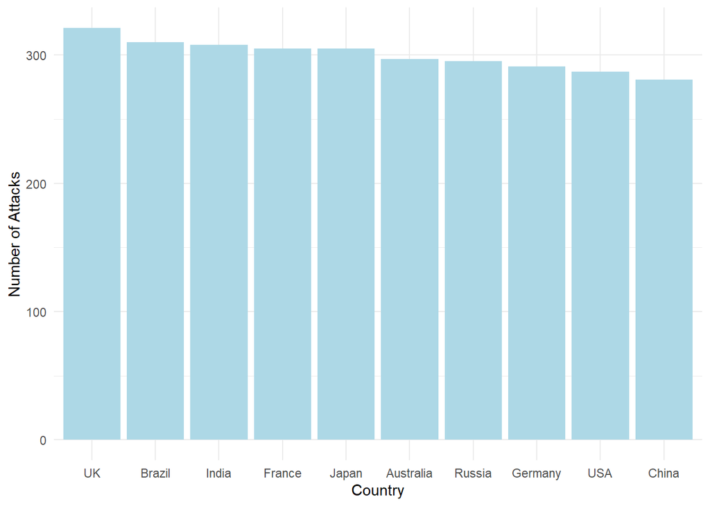

First, we analyzed which countries face the most cyberattacks by creating a bar chart, which aggregates the total number of attacks by country. The **UK** experienced the highest number of attacks, followed by **Brazil** and **India**. In contrast, **China** and the **United States** had the fewest attacks during this period.

Overall, the distribution of attack counts is fairly balanced across countries, suggesting that cybersecurity threats are a global issue rather than being concentrated in a region between 2015 and 2024.

## 2. How have cybersecurity attacks changed over time?

| Year | Number_of_Attacks |
| --- | --- |
| 2015 | 277 |
| 2016 | 285 |
| 2017 | 319 |
| 2018 | 310 |
| 2019 | 263 |
| 2020 | 315 |
| 2021 | 299 |
| 2022 | 318 |
| 2023 | 315 |
| 2024 | 299 |

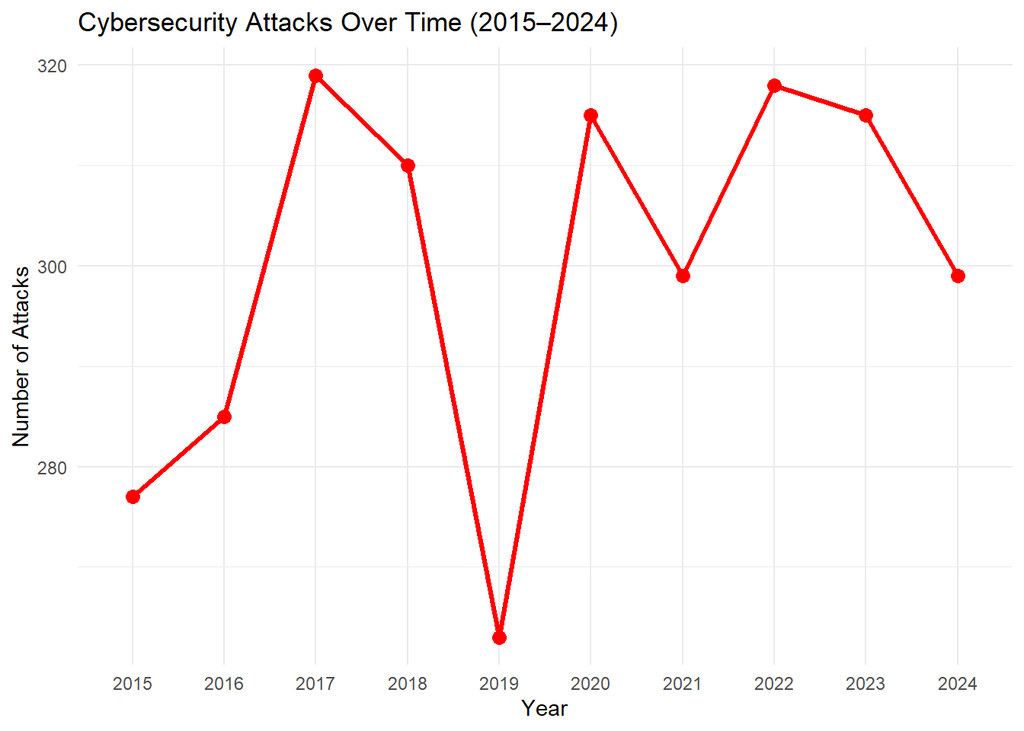

The line plot shows the number of cybersecurity attacks per year from 2015 to 2024. Overall, the number of attacks has fluctuated. There is no clear long-term upward or downward trend. However, the most noticeable dip occurred in 2019, when attacks fell to 263, compared to a high of 319 in 2017.

## 3. What are the most common types of cybersecurity threats?

| Attack.Type | Frequency |
| --- | --- |
| DDoS | 531 |
| Phishing | 529 |
| SQL Injection | 503 |
| Ransomware | 493 |
| Malware | 485 |
| Man-in-the-Middle | 459 |

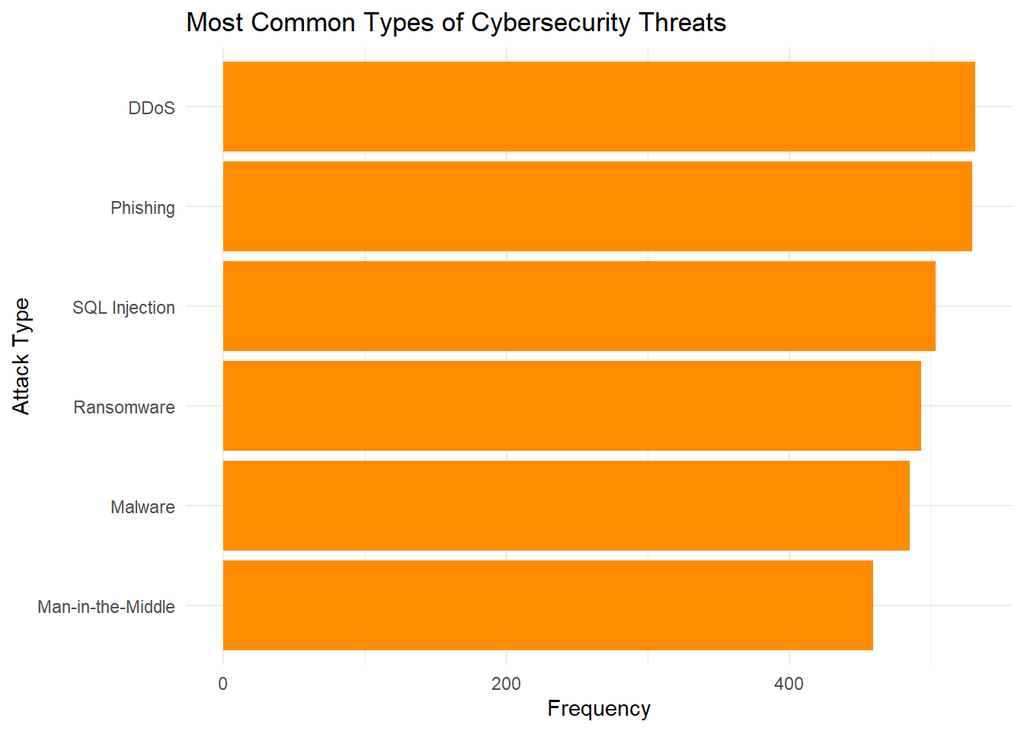

The top three most common types of cybersecurity threats are DDoS (Distributed Denial of Service) attacks, phishing, and SQL injection. DDoS attacks lead the list with a little over 500 reported cases. Phishing remains widespread; It tricks users into revealing sensitive information like passwords and credit card numbers.

SQL injection is also a major concern. Hackers can access or manipulate databases by exploiting vulnerabilities. On the other hand, ransomware, malware, and man-in-the-middle (MitM) attacks comprise the bottom three threats, with a little more than 400 incidents reported. While less frequent, these threats still pose risks by compromising data, locking users out of systems, or intercepting private communications.

## 4. Which vulnerabilities are most commonly exploited in cyberattacks?

| Security.Vulnerability.Type | Frequency |
| --- | --- |
| Zero-day | 785 |
| Social Engineering | 747 |
| Unpatched Software | 738 |
| Weak Passwords | 730 |

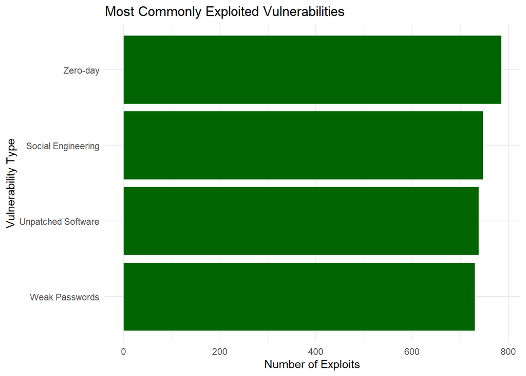

The most exploited vulnerability type is Zero-day, with 785 reported cases, where attackers take advantage of bugs before patches are released. Next is social engineering, which tricks users into revealing sensitive information. Unpatched software follows because outdated systems often have weaknesses. Weak passwords come last with 730 incidents, allowing for attackers to gain easy access. These vulnerabilities demonstrate the need for strong passwords, regular updates, and user awareness to improve cybersecurity.

## 5. Which industries are most affected by cyberattacks?

| Target.Industry | Frequency |
| --- | --- |
| IT | 478 |
| Banking | 445 |
| Healthcare | 429 |
| Retail | 423 |
| Education | 419 |
| Government | 403 |
| Telecommunications | 403 |

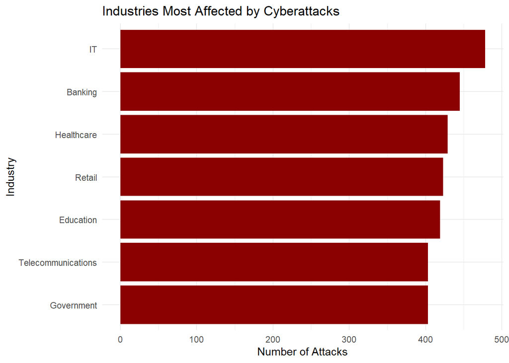

## 6. What is the relationship between number of affected users and financial impact?

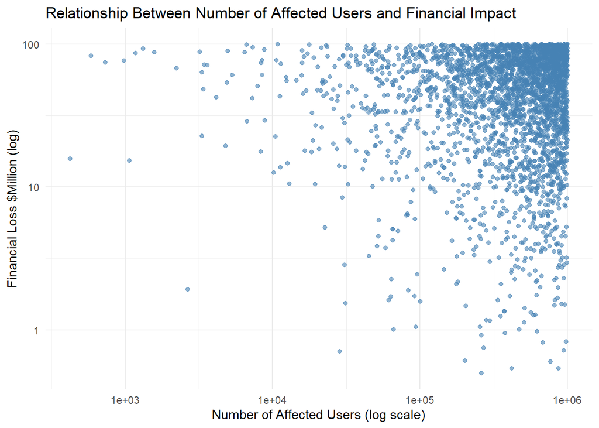

```
## Correlation between affected users and financial loss: 0.002
```

From the data, there appears to be no relationship between the number of affected users and financial losses. The correlation is just 0.002, indicating virtually no linear connection between the two. This means that even if more users are affected, it doesn’t necessarily lead to higher financial losses. The relationship is so weak it may be due to chance or other unmeasured factors. Overall, the number of affected users is not a strong predictor of financial loss in this dataset.

## 7. How does resolution time vary by severity level?

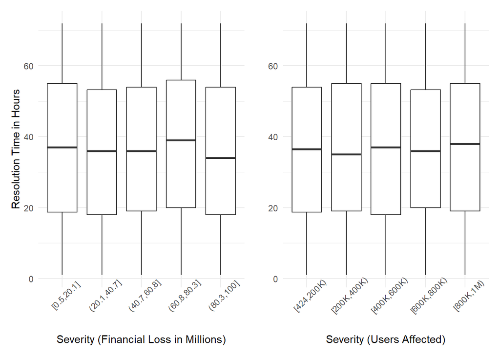

This set of boxplots compares the distribution of resolution times (in hours) for cybersecurity incidents across five severity levels, measured by two criteria: `Financial loss` (in millions of USD) and `Number of Users Affected` .

## 8. Which mitigation strategies are most effective/worse in reducing financial impact?

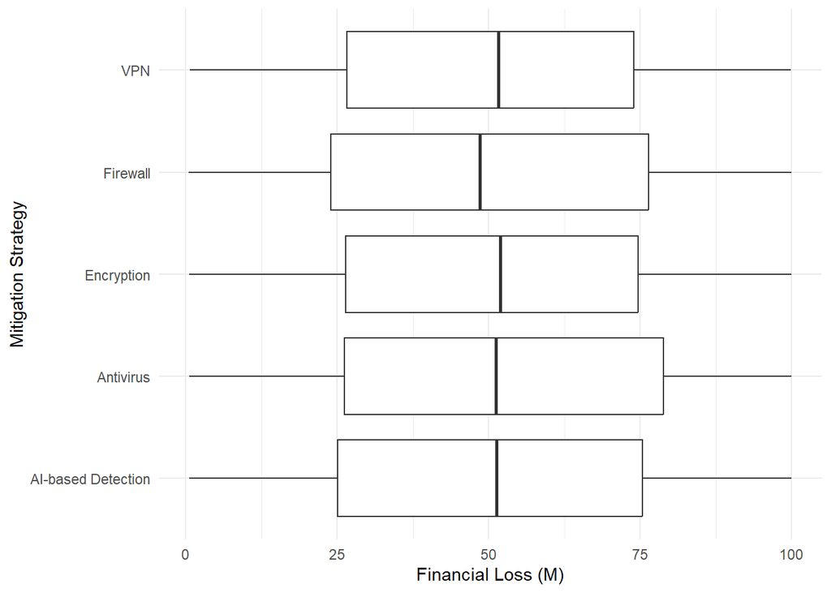

Median, IQR, and 90th percentile of Loss in Millions

| defense | median | IQR | 90th percentile |
| --- | --- | --- | --- |
| Encryption | 51.925 | 48.3150 | 88.800 |
| Firewall | 48.570 | 52.3700 | 89.094 |
| VPN | 51.560 | 47.2975 | 89.473 |
| AI-based Detection | 51.330 | 50.2750 | 90.026 |
| Antivirus | 51.145 | 52.6075 | 91.093 |

This boxplot compares the distribution of financial losses (in millions of USD) for five different cybersecurity defense strategies: **Encryption, Firewall, VPN, AI-based Detection, and Antivirus**.

All five strategies show a similar distribution of losses, with median values clustered around $51-$52 Million. However, **Firewall** shows a slightly lower median and a comparable interquartile range (IQR), suggesting marginally better performance in limiting financial damage.

Another option is to look at the worst-case scenarios using a percentile of the loss variable, which we see in the table. Specifically, **Antivirus** has the highest 90th percentile loss, indicating that in the worst 10% of cases, it performs worse than the others.

Overall, no strategy appears drastically more effective than the others in reducing financial losses. The close medians and similar IQRs suggest that financial impact is insensitive to the defense method used, or that other factors might be more influential. The slightly lower losses for Firewall imply that it is a strong traditional defense strategy. Also, while these numbers are close, we must think about the scale; Firewall has a median loss that is two million USD lower than other defenses and a few million dollars are still significant.

## 9. How does the volume of data breached vary across industries?

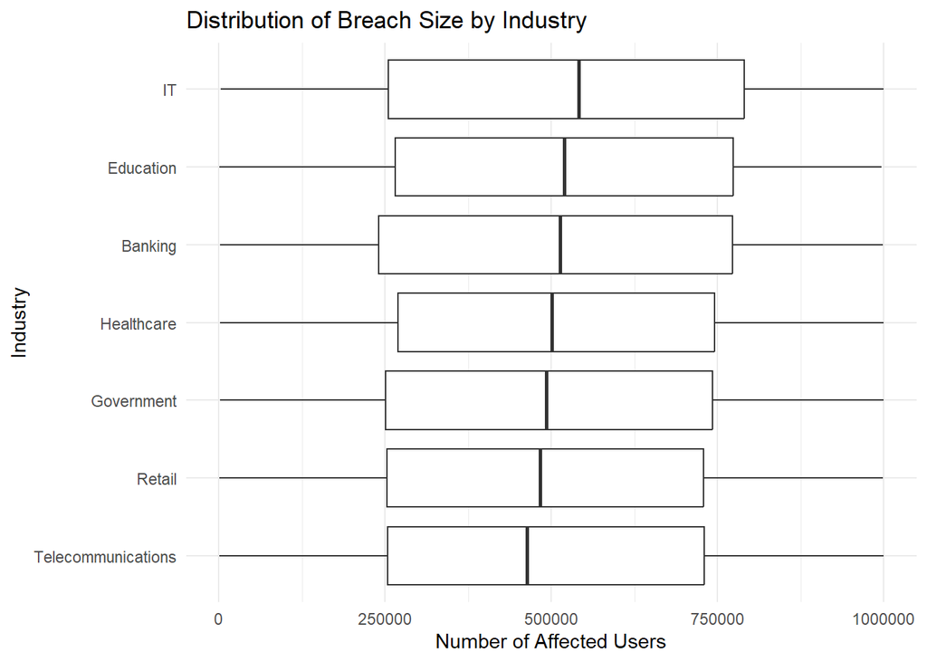

We wanted to analyze whether different industries have varying amounts of data breached in cyberattacks. A good metric for volume of data breached would be the variable `Affected Users`. Thus, these are boxplots for each `industry`: Banking, Education, Government, Healthcare, Retail, IT, and Telecommunications.

The seven industries have similar amounts of data breached for cyberattacks. The median for all industries remains close to 500,000 users. However, the IT industry seems to have a slightly higher breach size compared to other groups, which makes sense, companies in the IT sector would expect to have bigger issues with cyberattacks. Further, we can see that Telecommunications and Retail industries have the smallest median affected users for cyberattacks during the nine year period.

Perhaps, a t-test of `IT` versus `Telecommunications` will confirm that there is no difference in users affected among the different industries.

```r
Tele_loss <- cyber_data |> filter(industry == 'Telecommunications')
IT_loss <- cyber_data |> filter(industry == 'IT')

t.test(Tele_loss$users_affected, IT_loss$users_affected)
```

```
##
##  Welch Two Sample t-test
##
## data:  Tele_loss$users_affected and IT_loss$users_affected
## t = -1.4406, df = 863.33, p-value = 0.1501
## alternative hypothesis: true difference in means is not equal to 0
## 95 percent confidence interval:
##  -66166.04  10151.66
## sample estimates:
## mean of x mean of y
##  495203.7  523210.9
```

The t-test yields a p-value of 0.15, which is greater than the standard alpha (0.05). Therefore, we fail to reject that mean users affected in `IT` is the same as mean users affected in the `Telecommunications` industry. In summary, these are small differences between industries and are insufficient to label as a trend in `Users Affected`.

## 10. Which countries had the highest and lowest financial losses due to cyberattacks in 2019, when there were less attacks?

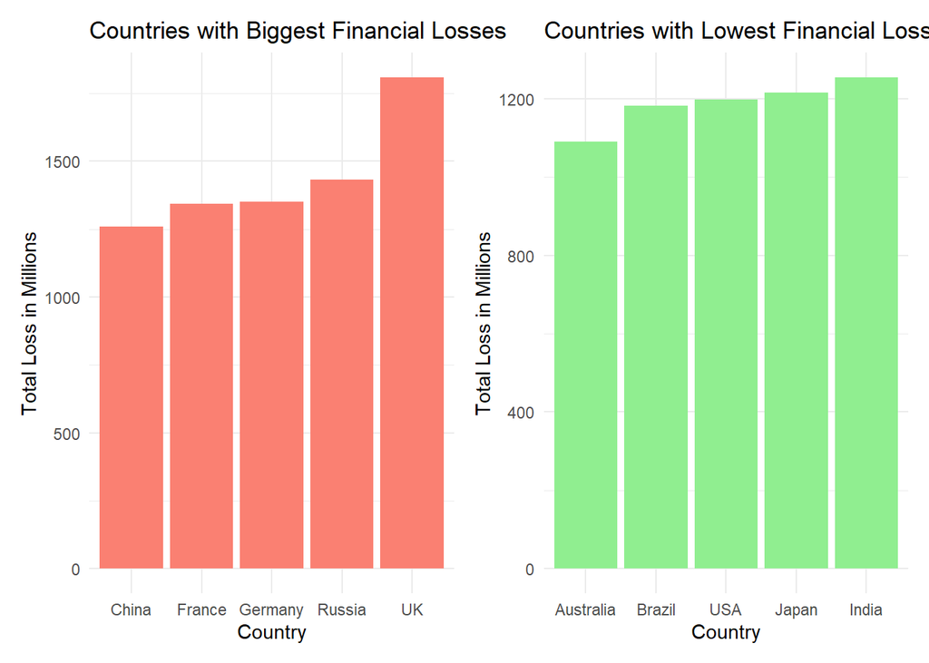

In 2019, there were less attacks compared to other years in 2015-2024. It would be interesting to see how financial loss varied by country during this period.

The two bar charts display the countries that had the biggest financial losses in 2019 in red and those that had the smallest financial losses in 2019 in green. First, the **UK** has the biggest total financial losses (close to $1.8 Billion) due to cyberattacks, then Russia followed with ~$1.4 Billion. Further, **Australia**, **Brazil**, and the **US** had the smallest losses in 2019. Australia recorded ~$1.1 billion dollars in losses that year.

The **UK** seemed to have almost twice as large losses as some other countries this year. So, let us instead look at average loss per attack since there are a different number of attacks for different countries.

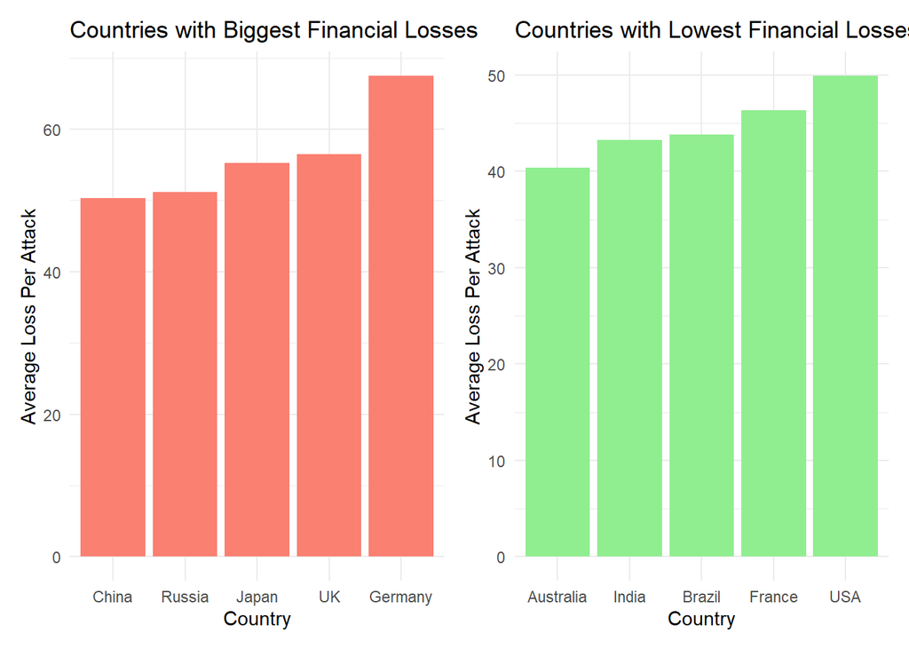

Now we see a different leader in financial losses when accounting for the number of attacks a country faced in 2019: **Germany**. On average, **Germany** had the largest loss per attack at nearly $70 Million, and the **UK** and **Japan** followed with over $50 Million average loss. Additionally, now the countries that had the smallest loss per attack were **Australia, India, and Brazil** respectively. On average, **Australia** lost $40 Million per attack in 2019 with **India** and **Brazil** losing close to $45 Million per attack.

# Conclusion:

DDoS and phishing were the most common types of threats, and zero-day vulnerabilities were the most frequently exploited, which highlights the technical and human elements in cybersecurity attacks. Also, the number of users affected by an attack did not correlate strongly with financial losses, suggesting that the scale of user impact alone is not a great predictor of economic damage.

Across seven different industries, breach sizes were consistent, with IT seeing slightly higher user impact, likely due to the vast data that IT companies have. Resolution time did not vary significantly by severity, and mitigation strategies showed only marginal differences in effectiveness, with firewall defenses performing slightly better in median financial losses.

A simple linear model is not sufficient for predicting financial loss for this dataset. We would expand on this analysis by applying non-linear models or other supervised learning techniques to identify which features most influence financial loss. This could help uncover deeper relationships that aren’t apparent through exploratory analysis. Ultimately it would guide more targeted and effective cybersecurity strategies.